# MARS MRT: Day-Level Analyses

January 11, 2024

# 1 Description of set up

## 1.1 Variables included in the time-varying effect models (Tan, et al., 2012)

- $\text{NO. OF CIGARETTES SMOKED}_{i} \left(t_{i,j}\right)$ denotes total number of cigarettes smoked reported by participant $i$ in EMAs on day $j$
- $\text{NO. OF CIGARETTES SMOKED}_{i} \left(t_{i,j+1}\right)$ denotes total number of cigarettes smoked reported by participant $i$ in EMAs on day $j+1$
- $\text{NO. OF TIMES ENGAGED}_{i} \left(t_{i,j}\right)$ denotes total number of times engagement in self-regulatory strategies was reported by participant $i$ in EMAs on day $j$
- $\text{NO. OF PROMPTS}_{i} \left(t_{i,j-1}\right)$ denotes total number of times participant $i$ was assigned to **prompt** (any kind) on day $j-1$
- $\text{NO. OF HIGH EFFORT PROMPTS}_{i} \left(t_{i,j-1}\right)$ denotes total number of times participant $i$ was assigned to **high effort prompt** on day $j-1$
- $\text{NO. OF LOW EFFORT PROMPTS}_{i} \left(t_{i,j-1}\right)$ denotes total number of times participant $i$ was assigned to **low effort prompt** on day $j-1$

## 1.2 Defining time

- $t_{i,j}$ denotes the “time” at which day $j$ of person $i$ occurred.
  - In this write-up, “time” is operationalized as day in study: that is, $t_{i,j} = j$ and $j = 2,3,4,5,6,7,8,9$.
  - **Definition of TVEM “origin time” for all models:** The 2nd day ($j=2$) which corresponds to the first day after the first clinic visit.

## 1.3 References

Tan, X., Shiyko, M. P., Li, R., Li, Y., and Dierker, L. (2012). A time-varying effect model for intensive longitudinal data. Psychological methods, 17(1), 61.

# 2 Intercept-only TVEM

$$\text{NO. OF CIGARETTES SMOKED}_{i} \left(t_{i,j} \right) = \beta_0
\left(t_{i,j}\right)$$

```r
dat_summary_observed <- dat_for_analysis %>%
    filter(n_elig > 0) %>%
    group_by(n_elig == n_obs_cigs) %>%
    summarise(total = n())

dat_summary_observed
```

```
## # A tibble: 2 × 2
##   `n_elig == n_obs_cigs` total
##   <lgl>                  <int>
## 1 FALSE                    567
## 2 TRUE                     148
```

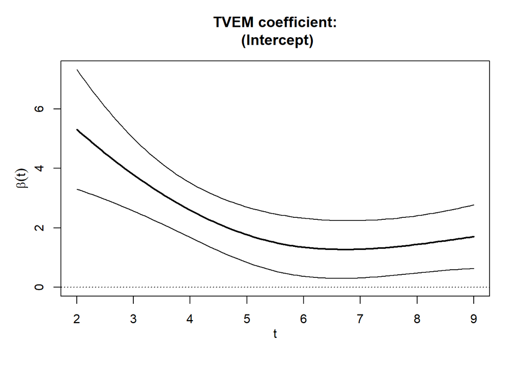

$$\text{NO. OF TIMES ENGAGED}_{i} \left(t_{i,j} \right) = \beta_0
\left(t_{i,j}\right)$$

```r
dat_summary_observed <- dat_for_analysis %>%
    filter(n_elig > 0) %>%
    group_by(n_elig == n_obs_cigs) %>%
    summarise(total = n())

dat_summary_observed
```

```
## # A tibble: 2 × 2
##   `n_elig == n_obs_cigs` total
##   <lgl>                  <int>
## 1 FALSE                    567
## 2 TRUE                     148
```

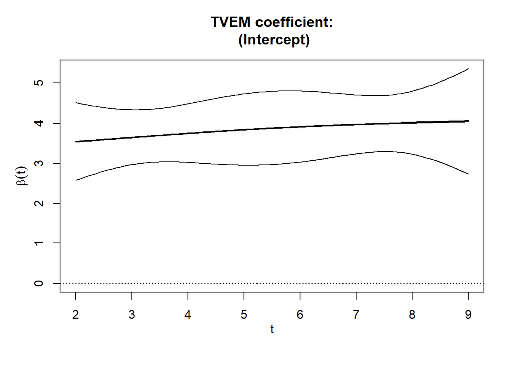

$$\text{NO. OF PROMPTS}_{i} \left(t_{i,j} \right) = \beta_0
\left(t_{i,j}\right)$$

```r
dat_summary_observed <- dat_for_analysis %>%
    filter(n_elig > 0) %>%
    group_by(n_elig == n_obs_cigs) %>%
    summarise(total = n())

dat_summary_observed
```

```
## # A tibble: 2 × 2
##   `n_elig == n_obs_cigs` total
##   <lgl>                  <int>
## 1 FALSE                    567
## 2 TRUE                     148
```

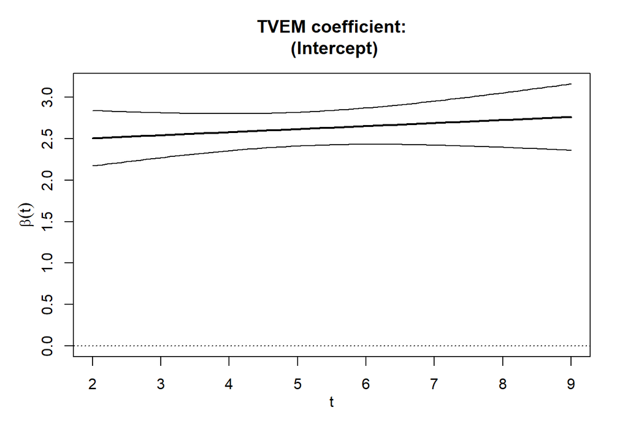

$$\text{NO. OF HIGH EFFORT PROMPTS}_{i} \left(t_{i,j} \right) = \beta_0
\left(t_{i,j}\right)$$

```r
dat_summary_observed <- dat_for_analysis %>%
    filter(n_elig > 0) %>%
    group_by(n_elig == n_obs_cigs) %>%
    summarise(total = n())

dat_summary_observed
```

```
## # A tibble: 2 × 2
##   `n_elig == n_obs_cigs` total
##   <lgl>                  <int>
## 1 FALSE                    567
## 2 TRUE                     148
```

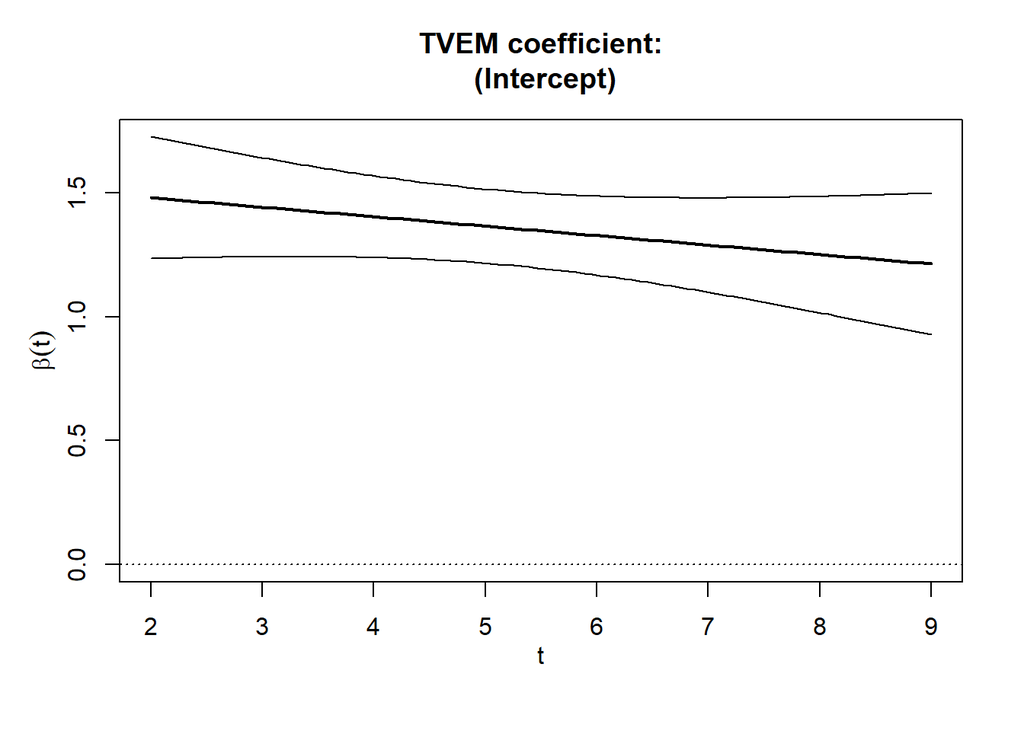

$$\text{NO. OF LOW EFFORT PROMPTS}_{i} \left(t_{i,j} \right) = \beta_0
\left(t_{i,j}\right)$$

```r
dat_summary_observed <- dat_for_analysis %>%
    filter(n_elig > 0) %>%
    group_by(n_elig == n_obs_cigs) %>%
    summarise(total = n())

dat_summary_observed
```

```
## # A tibble: 2 × 2
##   `n_elig == n_obs_cigs` total
##   <lgl>                  <int>
## 1 FALSE                    567
## 2 TRUE                     148
```

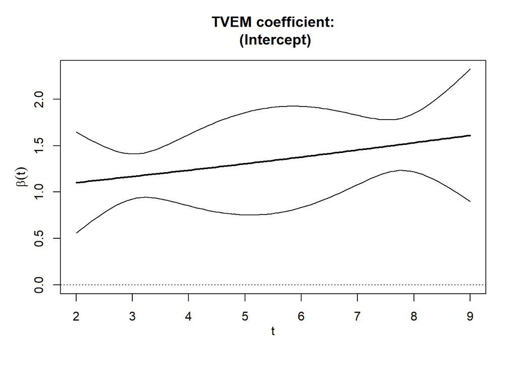

# 3 No. of cigarettes smoked on current day as outcome

$$\text{NO. OF CIGARETTES SMOKED}_{i} \left(t_{i,j} \right) = \beta_0
\left(t_{i,j}\right) + \beta_1 \left(t_{i,j}\right) \text{NO. OF TIMES
ENGAGED} \left(t_{i,j}\right)$$

```r
dat_summary_observed <- dat_for_analysis %>%
    filter(n_elig > 0) %>%
    group_by(n_elig == n_obs_cigs) %>%
    summarise(total = n())

dat_summary_observed
```

```
## # A tibble: 2 × 2
##   `n_elig == n_obs_cigs` total
##   <lgl>                  <int>
## 1 FALSE                    567
## 2 TRUE                     148
```

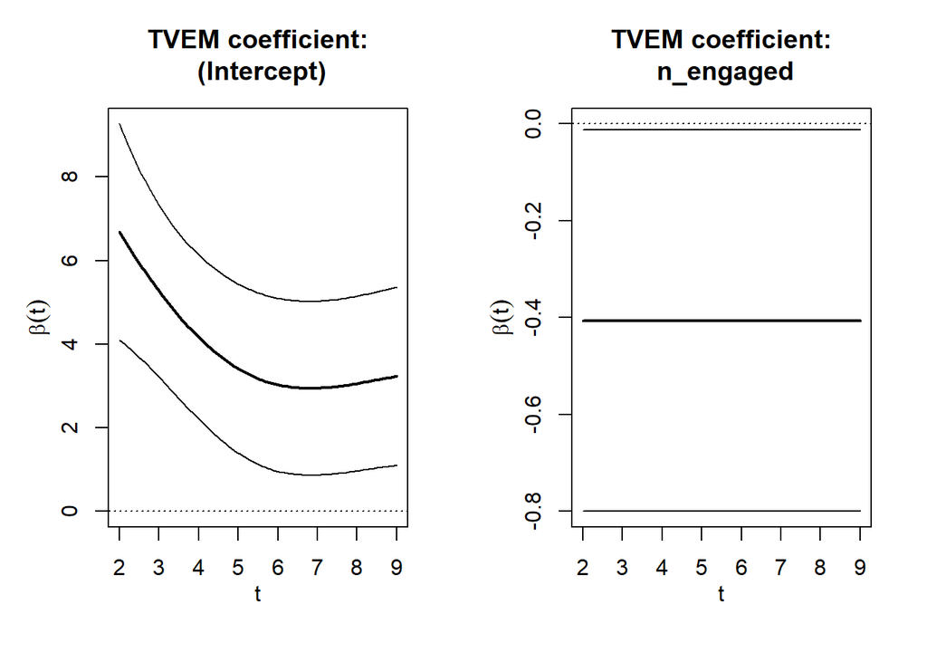

```r
dat_summary_observed <- dat_for_analysis %>%
    filter((n_elig > 0) & (n_elig_lag1 > 0)) %>%
    group_by((n_elig == n_obs_cigs) & (n_elig_lag1 == n_obs_cigs_lag1)) %>%
    summarise(total = n())

dat_summary_observed
```

```
## # A tibble: 2 × 2
##   `(n_elig == n_obs_cigs) & (n_elig_lag1 == n_obs_cigs_lag1)` total
##   <lgl>                                                       <int>
## 1 FALSE                                                         609
## 2 TRUE                                                           71
```

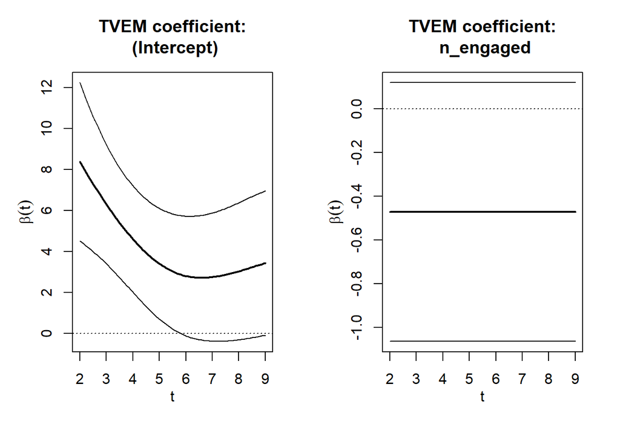

$$\text{NO. OF CIGARETTES SMOKED}_{i} \left(t_{i,j} \right) = \beta_0
\left(t_{i,j}\right) + \beta_1 \left(t_{i,j}\right) \text{NO. OF
PROMPTS} \left(t_{i,j}\right)$$

```r
dat_summary_observed <- dat_for_analysis %>%
    filter(n_elig > 0) %>%
    group_by(n_elig == n_obs_cigs) %>%
    summarise(total = n())

dat_summary_observed
```

```
## # A tibble: 2 × 2
##   `n_elig == n_obs_cigs` total
##   <lgl>                  <int>
## 1 FALSE                    567
## 2 TRUE                     148
```

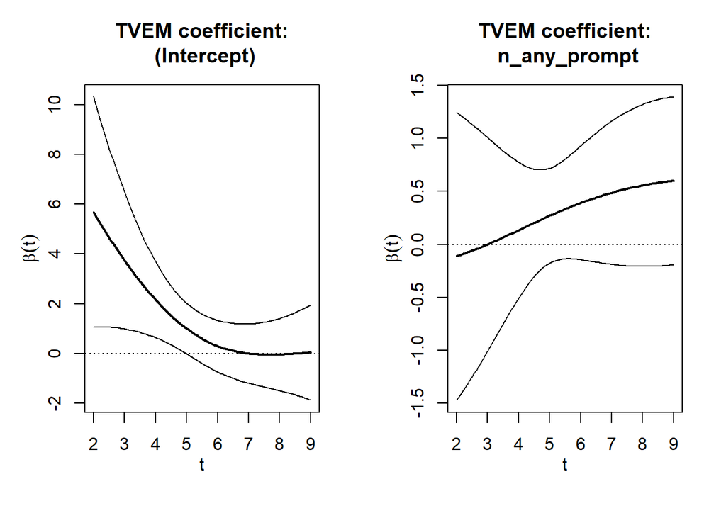

$$\text{NO. OF CIGARETTES SMOKED}_{i} \left(t_{i,j} \right) = \beta_0
\left(t_{i,j}\right) + \beta_1 \left(t_{i,j}\right) \text{NO. OF
PROMPTS} \left(t_{i,j-1}\right)$$

```r
dat_summary_observed <- dat_for_analysis %>%
    filter(n_elig > 0) %>%
    group_by(n_elig == n_obs_cigs) %>%
    summarise(total = n())

dat_summary_observed
```

```
## # A tibble: 2 × 2
##   `n_elig == n_obs_cigs` total
##   <lgl>                  <int>
## 1 FALSE                    567
## 2 TRUE                     148
```

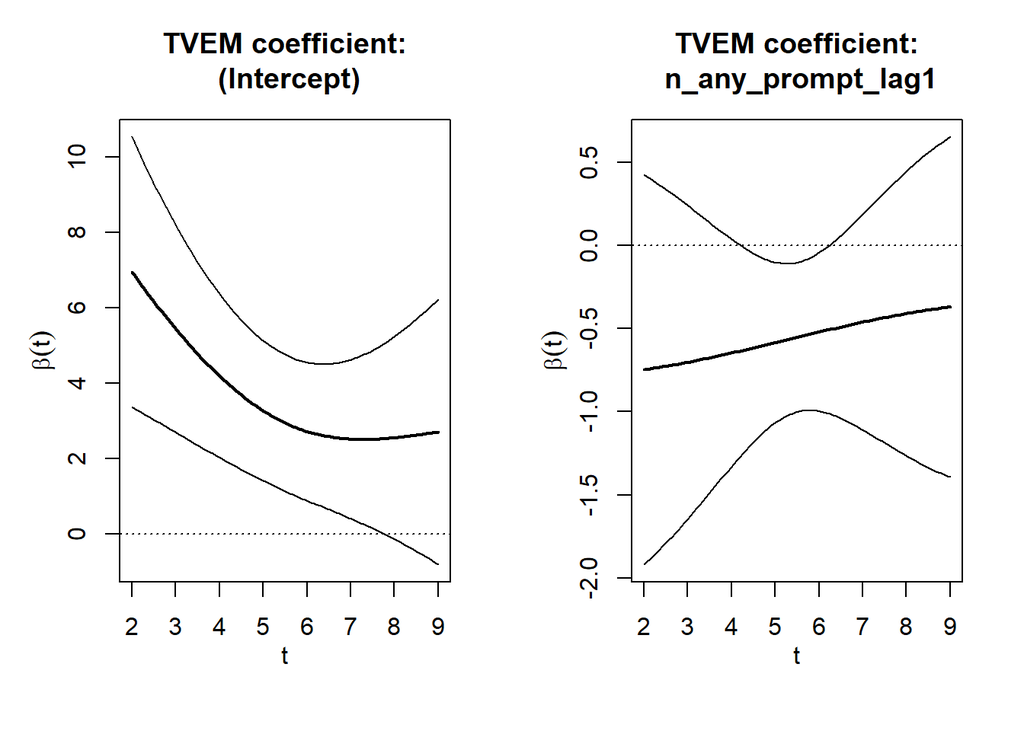

$$\text{NO. OF CIGARETTES SMOKED}_{i} \left(t_{i,j} \right) = \beta_0
\left(t_{i,j}\right) + \beta_1 \left(t_{i,j}\right) \text{NO. OF
PROMPTS} \left(t_{i,j-1}\right) + \beta_2 \left(t_{i,j}\right) \text{NO.
OF CIGARETTES SMOKED} \left(t_{i,j-1}\right)$$

```r
dat_summary_observed <- dat_for_analysis %>%
    filter((n_elig > 0) & (n_elig_lag1 > 0)) %>%
    group_by((n_elig == n_obs_cigs) & (n_elig_lag1 == n_obs_cigs_lag1)) %>%
    summarise(total = n())

dat_summary_observed
```

```
## # A tibble: 2 × 2
##   `(n_elig == n_obs_cigs) & (n_elig_lag1 == n_obs_cigs_lag1)` total
##   <lgl>                                                       <int>
## 1 FALSE                                                         609
## 2 TRUE                                                           71
```

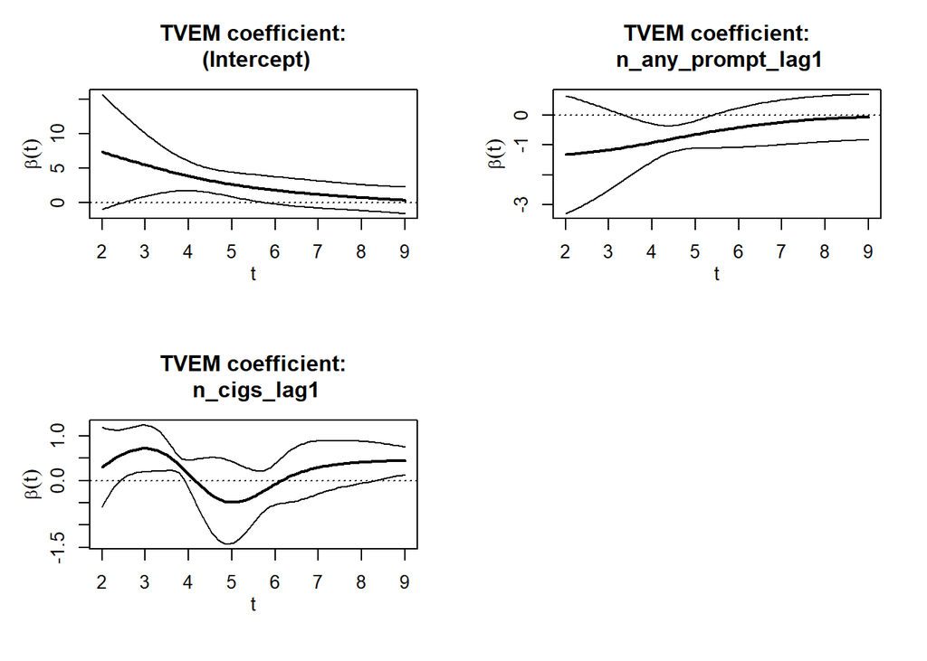

$$\text{NO. OF CIGARETTES SMOKED}_{i} \left(t_{i,j} \right) = \beta_0
\left(t_{i,j}\right) + \beta_1 \left(t_{i,j}\right) \text{NO. OF HIGH
EFFORT PROMPTS} \left(t_{i,j}\right)$$

```r
dat_summary_observed <- dat_for_analysis %>%
    filter(n_elig > 0) %>%
    group_by(n_elig == n_obs_cigs) %>%
    summarise(total = n())

dat_summary_observed
```

```
## # A tibble: 2 × 2
##   `n_elig == n_obs_cigs` total
##   <lgl>                  <int>
## 1 FALSE                    567
## 2 TRUE                     148
```

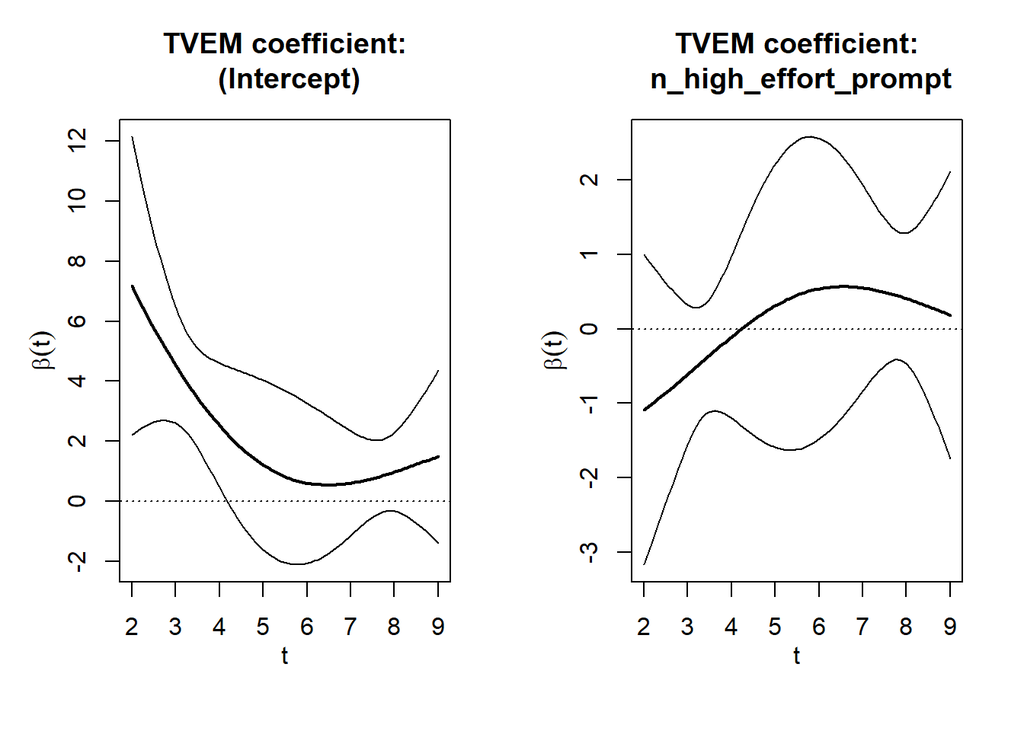

$$\text{NO. OF CIGARETTES SMOKED}_{i} \left(t_{i,j} \right) = \beta_0
\left(t_{i,j}\right) + \beta_1 \left(t_{i,j}\right) \text{NO. OF HIGH
EFFORT PROMPTS} \left(t_{i,j-1}\right)$$

```r
dat_summary_observed <- dat_for_analysis %>%
    filter((n_elig > 0) & (n_elig_lag1 > 0)) %>%
    group_by(n_elig == n_obs_cigs) %>%
    summarise(total = n())

dat_summary_observed
```

```
## # A tibble: 2 × 2
##   `n_elig == n_obs_cigs` total
##   <lgl>                  <int>
## 1 FALSE                    537
## 2 TRUE                     143
```

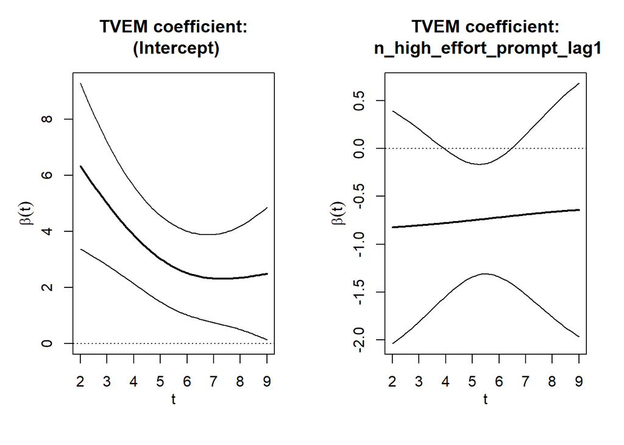

$$\text{NO. OF CIGARETTES SMOKED}_{i} \left(t_{i,j} \right) = \beta_0
\left(t_{i,j}\right) + \beta_1 \left(t_{i,j}\right) \text{NO. OF HIGH
EFFORT PROMPTS} \left(t_{i,j-1}\right) + \beta_2 \left(t_{i,j}\right)
\text{NO. OF CIGARETTES SMOKED} \left(t_{i,j-1}\right)$$

```r
dat_summary_observed <- dat_for_analysis %>%
    filter((n_elig > 0) & (n_elig_lag1 > 0)) %>%
    group_by((n_elig == n_obs_cigs) & (n_elig_lag1 == n_obs_cigs_lag1)) %>%
    summarise(total = n())

dat_summary_observed
```

```
## # A tibble: 2 × 2
##   `(n_elig == n_obs_cigs) & (n_elig_lag1 == n_obs_cigs_lag1)` total
##   <lgl>                                                       <int>
## 1 FALSE                                                         609
## 2 TRUE                                                           71
```

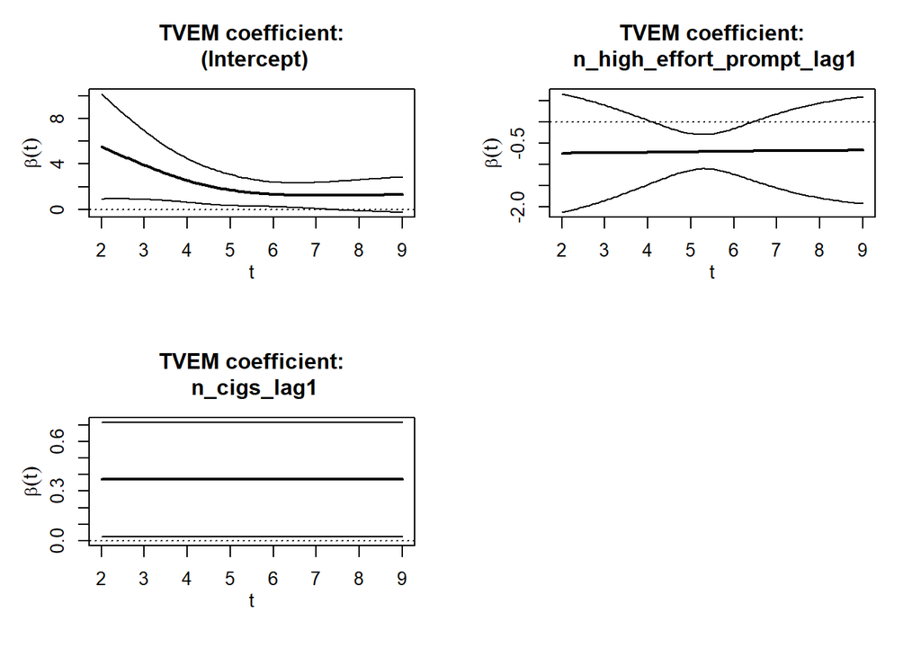

$$\text{NO. OF CIGARETTES SMOKED}_{i} \left(t_{i,j} \right) = \beta_0
\left(t_{i,j}\right) + \beta_1 \left(t_{i,j}\right) \text{NO. OF LOW
EFFORT PROMPTS} \left(t_{i,j}\right)$$

```r
dat_summary_observed <- dat_for_analysis %>%
    filter(n_elig > 0) %>%
    group_by(n_elig == n_obs_cigs) %>%
    summarise(total = n())

dat_summary_observed
```

```
## # A tibble: 2 × 2
##   `n_elig == n_obs_cigs` total
##   <lgl>                  <int>
## 1 FALSE                    567
## 2 TRUE                     148
```

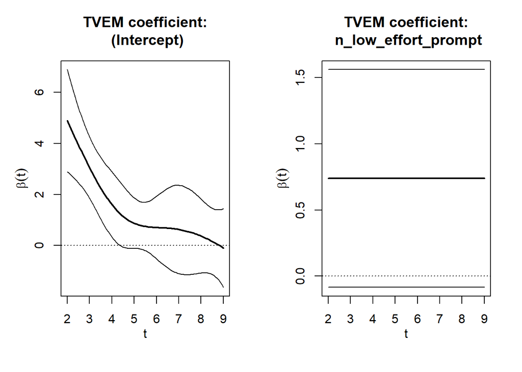

$$\text{NO. OF CIGARETTES SMOKED}_{i} \left(t_{i,j} \right) = \beta_0
\left(t_{i,j}\right) + \beta_1 \left(t_{i,j}\right) \text{NO. OF LOW
EFFORT PROMPTS} \left(t_{i,j-1}\right)$$

```r
dat_summary_observed <- dat_for_analysis %>%
    filter((n_elig > 0) & (n_elig_lag1 > 0)) %>%
    group_by(n_elig == n_obs_cigs) %>%
    summarise(total = n())

dat_summary_observed
```

```
## # A tibble: 2 × 2
##   `n_elig == n_obs_cigs` total
##   <lgl>                  <int>
## 1 FALSE                    537
## 2 TRUE                     143
```

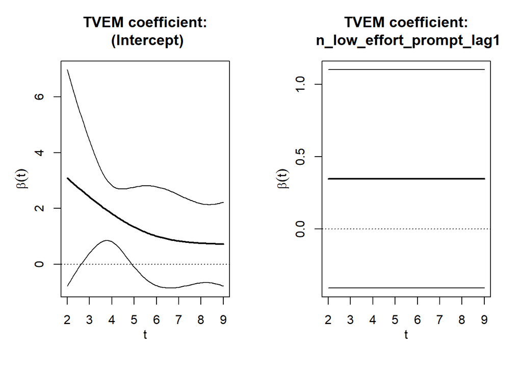

$$\text{NO. OF CIGARETTES SMOKED}_{i} \left(t_{i,j} \right) = \beta_0
\left(t_{i,j}\right) + \beta_1 \left(t_{i,j}\right) \text{NO. OF LOW
EFFORT PROMPTS} \left(t_{i,j-1}\right) + \beta_2 \left(t_{i,j}\right)
\text{NO. OF CIGARETTES SMOKED} \left(t_{i,j-1}\right)$$

```r
dat_summary_observed <- dat_for_analysis %>%
    filter((n_elig > 0) & (n_elig_lag1 > 0)) %>%
    group_by((n_elig == n_obs_cigs) & (n_elig_lag1 == n_obs_cigs_lag1)) %>%
    summarise(total = n())

dat_summary_observed
```

```
## # A tibble: 2 × 2
##   `(n_elig == n_obs_cigs) & (n_elig_lag1 == n_obs_cigs_lag1)` total
##   <lgl>                                                       <int>
## 1 FALSE                                                         609
## 2 TRUE                                                           71
```

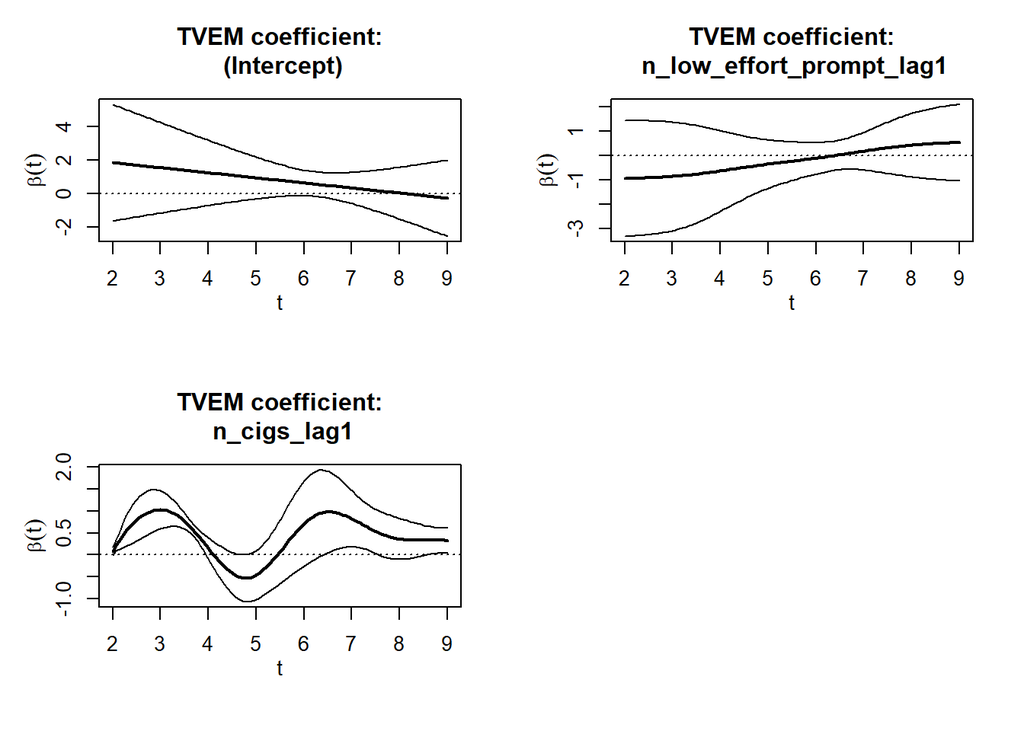

# 4 No. of cigarettes smoked on next day as outcome

```r
dat_summary_observed <- dat_for_analysis %>%
    filter((n_elig > 0) & (n_elig_lead1 > 0)) %>%
    group_by((n_elig == n_obs_engaged) & (n_elig_lead1 == n_obs_cigs_lead1)) %>%
    summarise(total = n())

dat_summary_observed
```

```
## # A tibble: 2 × 2
##   `(n_elig == n_obs_engaged) & (n_elig_lead1 == n_obs_cigs_lead1)` total
##   <lgl>                                                            <int>
## 1 FALSE                                                              596
## 2 TRUE                                                                69
```

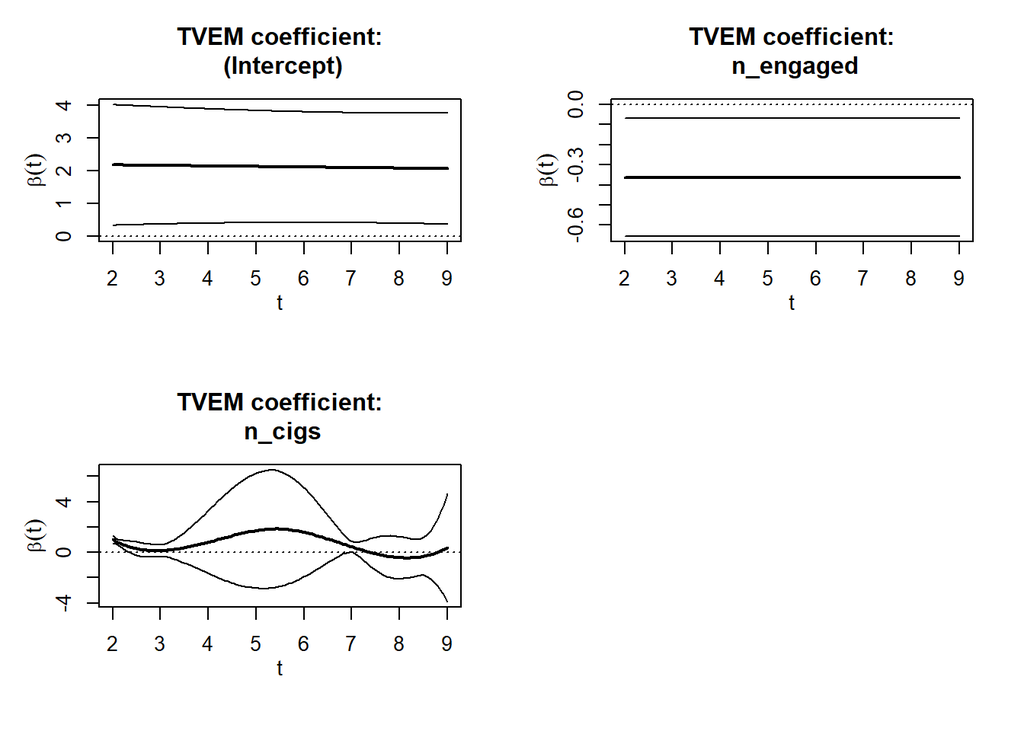

$$\text{NO. OF CIGARETTES SMOKED}_{i} \left(t_{i,j+1} \right) = \beta_0
\left(t_{i,j}\right) + \beta_1 \left(t_{i,j}\right) \text{NO. OF TIMES
ENGAGED} \left(t_{i,j}\right) + \beta_2 \left(t_{i,j}\right) \text{NO.
OF CIGARETTES SMOKED}_{i} \left(t_{i,j} \right)$$

```r
dat_summary_observed <- dat_for_analysis %>%
    filter((n_elig > 0) & (n_elig_lead1 > 0)) %>%
    group_by((n_elig == n_obs_engaged) & (n_elig_lead1 == n_obs_cigs_lead1)) %>%
    summarise(total = n())

dat_summary_observed
```

```
## # A tibble: 2 × 2
##   `(n_elig == n_obs_engaged) & (n_elig_lead1 == n_obs_cigs_lead1)` total
##   <lgl>                                                            <int>
## 1 FALSE                                                              596
## 2 TRUE                                                                69
```

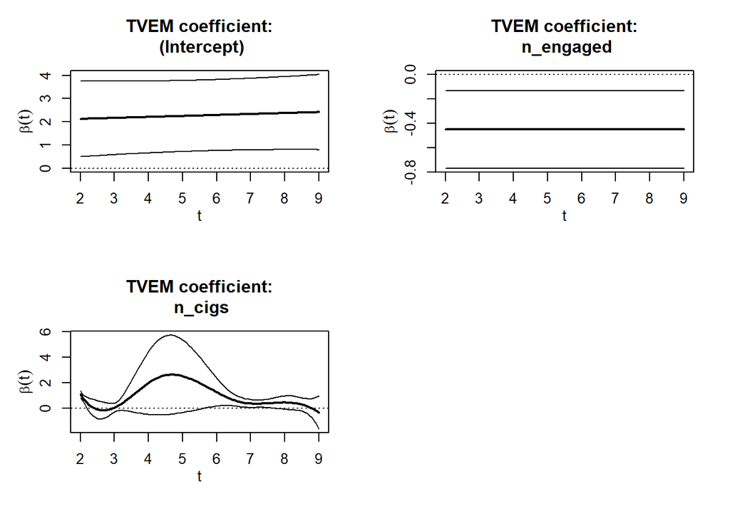